# BLACK FRIDAY SALES ANALYSIS

# **Project objective**

- Who are the customers?
- Which demographic groups purchase more?
- Which product categories generate more revenue?
- Which customers are high-value customers?
- Does gender affect purchasing behavior?
- Does marital status affect purchasing behavior?
- Which cities contribute more to sales?
- What products are commonly purchased together?
- What business strategies can be recommended?

### ABOUT DATASET:

**Dataset: Black Friday Sales Analysis**

- Number of Rows : 550068
- Number of Columns : 12
- Columns Include : User_ID,Product_ID,Gender,Age,Occupation,City_Category, Stay_In_Current_City_Years, Marital_Status,Product_Category_1,Product_Category_2, Product_Category_3 and Purchase.

**Data Overview**

The first step is to get a quick overview of the dataset. This gives an initial understanding of the dataset's structure, including the number of rows, columns, data types, sample data, and basic statistics.

### Actions:

- **Preview**: Displaying the first few rows of the data to get an idea of how it looks.
- **Shape**: Checking the number of rows and columns in the dataset.
- **Data types**: Understanding the data types for each column (e.g., numeric, categorical).
- **Summary Statistics**: Providing a statistical summary for the numerical features.

```python
# import libraries
import pandas as pd
import numpy as np
import matplotlib.pyplot as plt
import seaborn as sns
from scipy.stats import ttest_ind
from scipy import stats
```

# **Data Loading and Initial Overview**

```python
# step:1 load the dataset
df=pd.read_csv("Black Friday Data.csv")
```

```python
df.head()
```

|  | User_ID | Product_ID | Gender | Age | Occupation | City_Category | Stay_In_Current_City_Years | Marital_Status | Product_Category_1 | Product_Category_2 | Product_Category_3 | Purchase |
| --- | --- | --- | --- | --- | --- | --- | --- | --- | --- | --- | --- | --- |
| 0 | 1000001 | P00069042 | F | 0-17 | 10 | A | 2 | 0 | 3 | NaN | NaN | 8370 |
| 1 | 1000001 | P00248942 | F | 0-17 | 10 | A | 2 | 0 | 1 | 6.0 | 14.0 | 15200 |
| 2 | 1000001 | P00087842 | F | 0-17 | 10 | A | 2 | 0 | 12 | NaN | NaN | 1422 |
| 3 | 1000001 | P00085442 | F | 0-17 | 10 | A | 2 | 0 | 12 | 14.0 | NaN | 1057 |
| 4 | 1000002 | P00285442 | M | 55+ | 16 | C | 4+ | 0 | 8 | NaN | NaN | 7969 |

```python
# understand the dataset
df.shape
```

```
(550068, 12)
```

```python
# column names
df.columns
```

```
Index(['User_ID', 'Product_ID', 'Gender', 'Age', 'Occupation', 'City_Category',
       'Stay_In_Current_City_Years', 'Marital_Status', 'Product_Category_1',
       'Product_Category_2', 'Product_Category_3', 'Purchase'],
      dtype='object')
```

```python
# data types
df.dtypes
```

```
User_ID                         int64
Product_ID                     object
Gender                         object
Age                            object
Occupation                      int64
City_Category                  object
Stay_In_Current_City_Years     object
Marital_Status                  int64
Product_Category_1              int64
Product_Category_2            float64
Product_Category_3            float64
Purchase                        int64
dtype: object
```

```python
# dataset information
df.info()
```

```
<class 'pandas.core.frame.DataFrame'>
RangeIndex: 550068 entries, 0 to 550067
Data columns (total 12 columns):
 #   Column                      Non-Null Count   Dtype
---  ------                      --------------   -----
 0   User_ID                     550068 non-null  int64
 1   Product_ID                  550068 non-null  object
 2   Gender                      550068 non-null  object
 3   Age                         550068 non-null  object
 4   Occupation                  550068 non-null  int64
 5   City_Category               550068 non-null  object
 6   Stay_In_Current_City_Years  550068 non-null  object
 7   Marital_Status              550068 non-null  int64
 8   Product_Category_1          550068 non-null  int64
 9   Product_Category_2          376430 non-null  float64
 10  Product_Category_3          166821 non-null  float64
 11  Purchase                    550068 non-null  int64
dtypes: float64(2), int64(5), object(5)
memory usage: 50.4+ MB
```

```python
# Statistical summary
df.describe()
```

|  | User_ID | Occupation | Marital_Status | Product_Category_1 | Product_Category_2 | Product_Category_3 | Purchase |
| --- | --- | --- | --- | --- | --- | --- | --- |
| count | 5.500680e+05 | 550068.000000 | 550068.000000 | 550068.000000 | 376430.000000 | 166821.000000 | 550068.000000 |
| mean | 1.003029e+06 | 8.076707 | 0.409653 | 5.404270 | 9.842329 | 12.668243 | 9263.968713 |
| std | 1.727592e+03 | 6.522660 | 0.491770 | 3.936211 | 5.086590 | 4.125338 | 5023.065394 |
| min | 1.000001e+06 | 0.000000 | 0.000000 | 1.000000 | 2.000000 | 3.000000 | 12.000000 |
| 25% | 1.001516e+06 | 2.000000 | 0.000000 | 1.000000 | 5.000000 | 9.000000 | 5823.000000 |
| 50% | 1.003077e+06 | 7.000000 | 0.000000 | 5.000000 | 9.000000 | 14.000000 | 8047.000000 |
| 75% | 1.004478e+06 | 14.000000 | 1.000000 | 8.000000 | 15.000000 | 16.000000 | 12054.000000 |
| max | 1.006040e+06 | 20.000000 | 1.000000 | 20.000000 | 18.000000 | 18.000000 | 23961.000000 |

```python
# Data Quality Check
# Missing values
df.isnull().sum()
```

```
User_ID                            0
Product_ID                         0
Gender                             0
Age                                0
Occupation                         0
City_Category                      0
Stay_In_Current_City_Years         0
Marital_Status                     0
Product_Category_1                 0
Product_Category_2            173638
Product_Category_3            383247
Purchase                           0
dtype: int64
```

```python
# Also calculate percentage:
missing_percentage = df.isnull().mean() * 100

missing_percentage.sort_values(ascending=False)
```

```
Product_Category_3            69.672659
Product_Category_2            31.566643
User_ID                        0.000000
Product_ID                     0.000000
Gender                         0.000000
Age                            0.000000
Occupation                     0.000000
City_Category                  0.000000
Stay_In_Current_City_Years     0.000000
Marital_Status                 0.000000
Product_Category_1             0.000000
Purchase                       0.000000
dtype: float64
```

```python
# Duplicate Check
df.duplicated().sum()
```

```
0
```

```python
# Product Category 1
df["Product_Category_1"] = df["Product_Category_1"].astype(str)

# Product Category 2
df["Product_Category_2"] = (df["Product_Category_2"].fillna(0).astype(int).astype(str).replace("0", "Unknown"))

# Product Category 3
df["Product_Category_3"] = (df["Product_Category_3"].fillna(0).astype(int).astype(str).replace("0", "Unknown"))
```

Converted category columns to string as they are categorical variables. Replaced missing values in Category 2 & 3 with "Unknown" to preserve missing information.

### Checking Unique Values

Checked the unique values in all categorical columns to understand the different categories present in the dataset and identify any unexpected or inconsistent values.

```python
# Check Unique Values
for col in df.select_dtypes(include="object"):
    print("\n", col)
    print(df[col].unique())
```

```
 Product_ID
['P00069042' 'P00248942' 'P00087842' ... 'P00370293' 'P00371644'
 'P00370853']

 Gender
['F' 'M']

 Age
['0-17' '55+' '26-35' '46-50' '51-55' '36-45' '18-25']

 City_Category
['A' 'C' 'B']

 Stay_In_Current_City_Years
['2' '4+' '3' '1' '0']

 Product_Category_1
['3' '1' '12' '8' '5' '4' '2' '6' '14' '11' '13' '15' '7' '16' '18' '10'
 '17' '9' '20' '19']

 Product_Category_2
['Unknown' '6' '14' '2' '8' '15' '16' '11' '5' '3' '4' '12' '9' '10' '17'
 '13' '7' '18']

 Product_Category_3
['Unknown' '14' '17' '5' '4' '16' '15' '8' '9' '13' '6' '12' '3' '18' '11'
 '10']
```

```python
df.info()
```

```
<class 'pandas.core.frame.DataFrame'>
RangeIndex: 550068 entries, 0 to 550067
Data columns (total 12 columns):
 #   Column                      Non-Null Count   Dtype
---  ------                      --------------   -----
 0   User_ID                     550068 non-null  int64
 1   Product_ID                  550068 non-null  object
 2   Gender                      550068 non-null  object
 3   Age                         550068 non-null  object
 4   Occupation                  550068 non-null  int64
 5   City_Category               550068 non-null  object
 6   Stay_In_Current_City_Years  550068 non-null  object
 7   Marital_Status              550068 non-null  int64
 8   Product_Category_1          550068 non-null  object
 9   Product_Category_2          550068 non-null  object
 10  Product_Category_3          550068 non-null  object
 11  Purchase                    550068 non-null  int64
dtypes: int64(4), object(8)
memory usage: 50.4+ MB
```

# Exploratory Data Analysis

Most purchases are around ₹8,047.

Most purchases are below the average ₹9,264.

A few high purchases increase the average.

```python
# Exploratory Data Analysis
numerical_cols = ['Purchase']
mean_values      = df[numerical_cols].mean()
median_values    = df[numerical_cols].median()
mode_values      = df[numerical_cols].mode().iloc[0]
range_values     = df[numerical_cols].max() - df[numerical_cols].min()
variance_values  = df[numerical_cols].var()
std_dev_values   = df[numerical_cols].std()
skewness_values  = df[numerical_cols].skew()
kurtosis_values  = df[numerical_cols].kurt()

# Create Clean DataFrame
stats_df = pd.DataFrame({
    "Mean"              : mean_values,
    "Median"            : median_values,
    "Mode"              : mode_values,
    "Range"             : range_values,
    "Variance"          : variance_values,
    "Standard Deviation": std_dev_values,
    "Skewness"          : skewness_values,
    "Kurtosis"          : kurtosis_values
})

print(stats_df)
```

```
                 Mean  Median  Mode  Range      Variance  Standard Deviation  \
Purchase  9263.968713  8047.0  7011  23949  2.523119e+07         5023.065394

          Skewness  Kurtosis
Purchase   0.60014 -0.338378
```

# Purchase Analysis

```python
df["Purchase"].describe()
```

```
count    550068.000000
mean       9263.968713
std        5023.065394
min          12.000000
25%        5823.000000
50%        8047.000000
75%       12054.000000
max       23961.000000
Name: Purchase, dtype: float64
```

```python
# Minimum purchase
df["Purchase"].min()
```

```
12
```

```python
# Maximum purchase
df["Purchase"].max()
```

```
23961
```

```python
# Average purchase
df["Purchase"].mean()
```

```
9263.968712959126
```

```python
# Median purchase
df["Purchase"].median()
```

```
8047.0
```

# Outlier Analysis

```python
# Identify outliers
Q1 = df["Purchase"].quantile(0.25)
Q3 = df["Purchase"].quantile(0.75)

IQR = Q3 - Q1

lower_limit = Q1 - 1.5 * IQR
upper_limit = Q3 + 1.5 * IQR

print("Q1:", Q1)
print("Q3:", Q3)
print("IQR:", IQR)
print("Lower Limit:", lower_limit)
print("Upper Limit:", upper_limit)
```

```
Q1: 5823.0
Q3: 12054.0
IQR: 6231.0
Lower Limit: -3523.5
Upper Limit: 21400.5
```

```python
# Identify outliers using the IQR limits already computed
outliers = df[(df["Purchase"] < lower_limit) | (df["Purchase"] > upper_limit)]

print(f"Number of outliers: {len(outliers)}")
print(f"Percentage of data: {len(outliers)/len(df)*100:.2f}%")

# Inspect the highest outliers
outliers[["User_ID", "Product_ID", "Purchase"]].sort_values(
    "Purchase",
    ascending=False
).head(10)
```

```
Number of outliers: 2677
Percentage of data: 0.49%
```

|  | User_ID | Product_ID | Purchase |
| --- | --- | --- | --- |
| 87440 | 1001474 | P00052842 | 23961 |
| 93016 | 1002272 | P00052842 | 23961 |
| 370891 | 1003160 | P00052842 | 23961 |
| 292083 | 1003045 | P00052842 | 23960 |
| 503697 | 1005596 | P00117642 | 23960 |
| 321782 | 1001577 | P00052842 | 23960 |
| 349658 | 1005848 | P00119342 | 23960 |
| 437804 | 1001387 | P00086242 | 23959 |
| 298378 | 1003947 | P00116142 | 23959 |
| 7542 | 1001178 | P00116142 | 23958 |

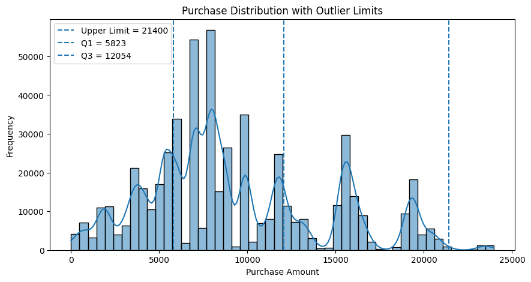

```python
plt.figure(figsize=(10, 5))

sns.histplot(df["Purchase"], bins=50, kde=True)

plt.axvline(
    upper_limit,
    linestyle="--",
    label=f"Upper Limit = {upper_limit:.0f}"
)

plt.axvline(
    Q1,
    linestyle="--",
    label=f"Q1 = {Q1:.0f}"
)

plt.axvline(
    Q3,
    linestyle="--",
    label=f"Q3 = {Q3:.0f}"
)

plt.title("Purchase Distribution with Outlier Limits")
plt.xlabel("Purchase Amount")
plt.ylabel("Frequency")
plt.legend()

plt.show()
```

Purpose: To identify the distribution of purchase amounts and detect potential outliers.

Histogram: Shows how purchase values are distributed.

Q1 & Q3: Show the middle 50% of purchase values.

Upper Limit: Helps identify unusually high purchases.

KDE line: Shows the overall shape of the distribution.

Conclusion: Most purchases are within the normal range, while values above 21,400 can be considered potential outliers.

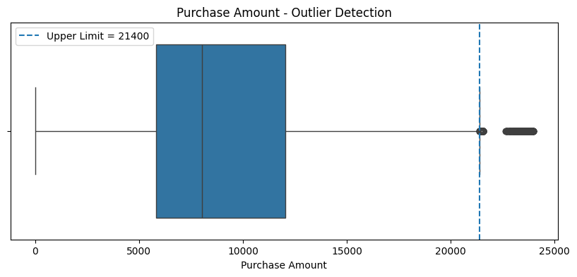

```python
plt.figure(figsize=(10, 4))

sns.boxplot(x=df["Purchase"])

plt.axvline(
    upper_limit,
    linestyle="--",
    label=f"Upper Limit = {upper_limit:.0f}"
)

plt.title("Purchase Amount - Outlier Detection")
plt.xlabel("Purchase Amount")
plt.legend()

plt.show()
```

Purpose: To identify and visualize outliers in purchase amounts.

Boxplot: Shows the spread of purchase values.

Blue dashed line: Represents the upper limit of 21,400.

Dots after the limit: Represent potential outliers.

Conclusion: Most purchases are within the normal range, while purchases above 21,400 are potential outliers.

The IQR method identified several extreme purchase values. Further investigation shows that these values represent valid transactions rather than data-entry errors. Therefore, the outliers were retained for analysis to avoid removing genuine high-value purchases.

# Univariate Analysis

Univariate Analysis: Studying one column/variable at a time to understand it better.

```python
# Gender
df["Gender"].value_counts(normalize=True).mul(100).round(2)
```

```
M    75.31
F    24.69
Name: Gender, dtype: float64
```

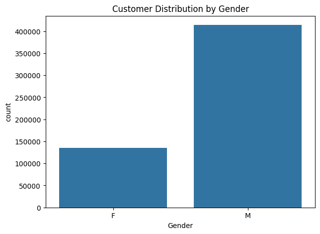

```python
# gender
plt.figure(figsize=(7,5))

sns.countplot(data=df, x="Gender")

plt.title("Customer Distribution by Gender")
plt.show()
```

Male customers are much higher than female customers.

The customer base is mostly male.

Female customers are much fewer.

```python
# Age
df["Age"].value_counts()
```

```
26-35    219587
36-45    110013
18-25     99660
46-50     45701
51-55     38501
55+       21504
0-17      15102
Name: Age, dtype: int64
```

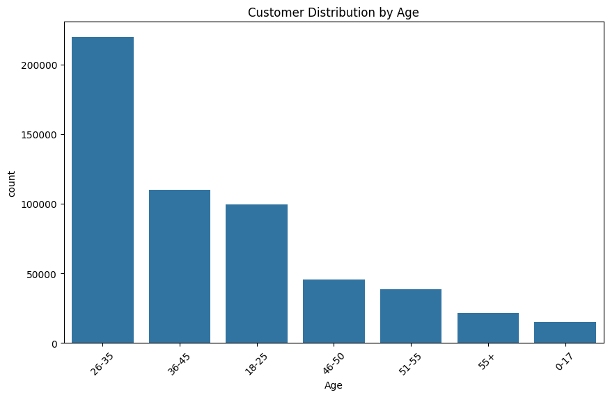

```python
# Age
plt.figure(figsize=(10,6))

sns.countplot(
    data=df,
    x="Age",
    order=df["Age"].value_counts().index
)

plt.title("Customer Distribution by Age")
plt.xticks(rotation=45)

plt.show()
```

26–35 age group has the highest number of customers.

36–45 is the second-highest group.

0–17 has the fewest customers.

Overall, customers are mainly in the 26–45 age groups.

```python
# City_Category
df["City_Category"].value_counts()
```

```
B    231173
C    171175
A    147720
Name: City_Category, dtype: int64
```

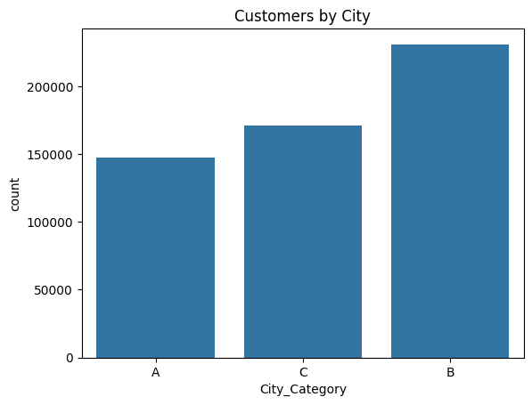

```python
# city_Category
sns.countplot(data=df, x="City_Category")

plt.title("Customers by City")
plt.show()
```

City B has the highest number of customers.

City C has fewer customers than City B but more than City A.

City A has the lowest number of customers.

```python
# Marital Status
df["Marital_Status"].value_counts()
```

```
0    324731
1    225337
Name: Marital_Status, dtype: int64
```

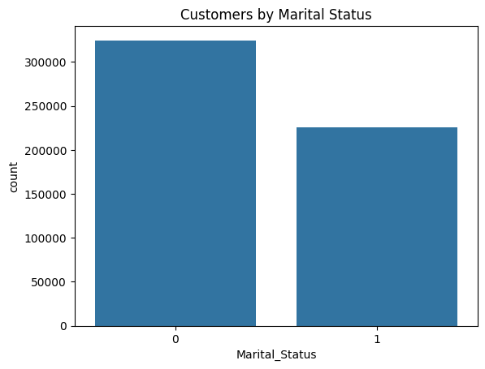

```python
# Marital Status
sns.countplot(data=df, x="Marital_Status")

plt.title("Customers by Marital Status")
plt.show()
```

Marital status 0 has more customers than marital status 1.

The customer base is mostly from marital status 0.

# Customer Demographic Analysis

```
Average items purchased per customer: 93.4
Median items purchased per customer: 54
Min items: 6, Max items: 1026
```

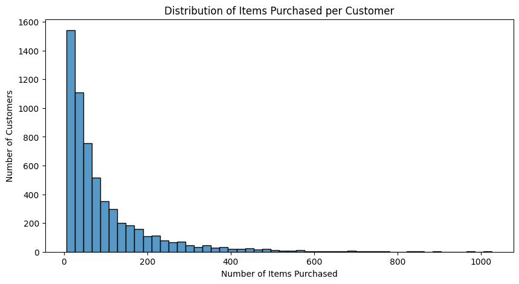

```python
customer_transactions = (
    df.groupby("User_ID").size().reset_index(name="Items_Purchased")
)

print(f"Average items purchased per customer: {customer_transactions['Items_Purchased'].mean():.1f}")
print(f"Median items purchased per customer: {customer_transactions['Items_Purchased'].median():.0f}")
print(f"Min items: {customer_transactions['Items_Purchased'].min()}, Max items: {customer_transactions['Items_Purchased'].max()}")

# Distribution view — more useful than a single "repeat rate" number
plt.figure(figsize=(10, 5))
sns.histplot(customer_transactions["Items_Purchased"], bins=50)
plt.title("Distribution of Items Purchased per Customer")
plt.xlabel("Number of Items Purchased")
plt.ylabel("Number of Customers")
plt.show()
```

This dataset records individual line items, not separate checkout sessions — so nearly every customer will appear multiple times regardless of loyalty.

A "repeat purchase rate" isn't meaningful here without an order ID or timestamp.

```python
# Gender vs Average Purchase
gender_purchase = df.groupby("Gender")["Purchase"].agg(
    ["count", "mean", "sum"]
)

gender_purchase
```

| Gender | count | mean | sum |
| --- | --- | --- | --- |
| F | 135809 | 8734.565765 | 1186232642 |
| M | 414259 | 9437.526040 | 3909580100 |

```python
# Age vs Purchase
age_purchase = df.groupby("Age")["Purchase"].agg(
    ["count", "mean", "sum"]
).sort_values("mean", ascending=False)

age_purchase
```

| Age | count | mean | sum |
| --- | --- | --- | --- |
| 51-55 | 38501 | 9534.808031 | 367099644 |
| 55+ | 21504 | 9336.280459 | 200767375 |
| 36-45 | 110013 | 9331.350695 | 1026569884 |
| 26-35 | 219587 | 9252.690633 | 2031770578 |
| 46-50 | 45701 | 9208.625697 | 420843403 |
| 18-25 | 99660 | 9169.663606 | 913848675 |
| 0-17 | 15102 | 8933.464640 | 134913183 |

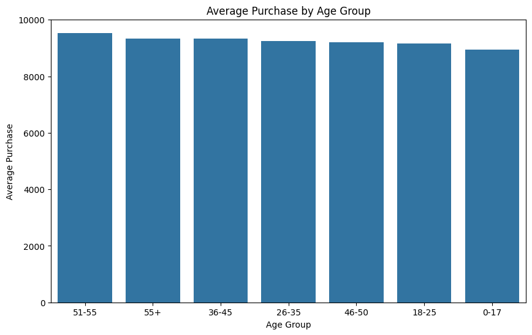

```python
plt.figure(figsize=(10,6))

sns.barplot(
    data=age_purchase.reset_index(),
    x="Age",
    y="mean"
)

plt.title("Average Purchase by Age Group")
plt.xlabel("Age Group")
plt.ylabel("Average Purchase")

plt.show()
```

Customers aged 51–55 spend the most per purchase on average, though this group is smaller in size than the 26–35 group.

```python
# City vs Purchase
city_purchase = df.groupby("City_Category")["Purchase"].agg(
    ["count", "mean", "sum"]
)

city_purchase
```

| City_Category | count | mean | sum |
| --- | --- | --- | --- |
| A | 147720 | 8911.939216 | 1316471661 |
| B | 231173 | 9151.300563 | 2115533605 |
| C | 171175 | 9719.920993 | 1663807476 |

```python
# Marital Status vs Purchase
marital_purchase = df.groupby("Marital_Status")["Purchase"].agg(
    ["count", "mean", "sum"]
)

marital_purchase
```

| Marital_Status | count | mean | sum |
| --- | --- | --- | --- |
| 0 | 324731 | 9265.907619 | 3008927447 |
| 1 | 225337 | 9261.174574 | 2086885295 |

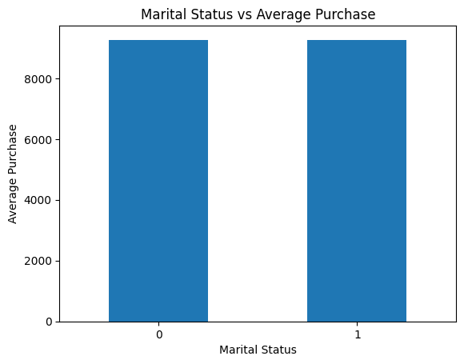

```python
# Marital Status vs Average Purchase

marital_purchase = df.groupby("Marital_Status")["Purchase"].mean()

marital_purchase.plot(kind="bar")

plt.xlabel("Marital Status")
plt.ylabel("Average Purchase")
plt.title("Marital Status vs Average Purchase")
plt.xticks(rotation=0)
plt.show()
```

```python
# Gender + Marital Status
gender_marital = df.groupby(
    ["Gender", "Marital_Status"]
)["Purchase"].mean().reset_index()

gender_marital
```

|  | Gender | Marital_Status | Purchase |
| --- | --- | --- | --- |
| 0 | F | 0 | 8679.845815 |
| 1 | F | 1 | 8810.249789 |
| 2 | M | 0 | 9453.756740 |
| 3 | M | 1 | 9413.817605 |

```python
# Product Analysis
# product category 1
product1 = df.groupby("Product_Category_1")["Purchase"].agg(
    ["count", "mean", "sum"]
).sort_values("sum", ascending=False)

product1.head(10)
```

| Product_Category_1 | count | mean | sum |
| --- | --- | --- | --- |
| 1 | 140378 | 13606.218596 | 1910013754 |
| 5 | 150933 | 6240.088178 | 941835229 |
| 8 | 113925 | 7498.958078 | 854318799 |
| 6 | 20466 | 15838.478550 | 324150302 |
| 2 | 23864 | 11251.935384 | 268516186 |
| 3 | 20213 | 10096.705734 | 204084713 |
| 16 | 9828 | 14766.037037 | 145120612 |
| 11 | 24287 | 4685.268456 | 113791115 |
| 10 | 5125 | 19675.570927 | 100837301 |
| 15 | 6290 | 14780.451828 | 92969042 |

```python
# Top Product Categories by Revenue
top_categories = (
    df.groupby("Product_Category_1")["Purchase"]
      .sum()
      .sort_values(ascending=False)
      .head(10)
)

top_categories
```

```
Product_Category_1
1     1910013754
5      941835229
8      854318799
6      324150302
2      268516186
3      204084713
16     145120612
11     113791115
10     100837301
15      92969042
Name: Purchase, dtype: int64
```

Top 10 Product Categories by Revenue

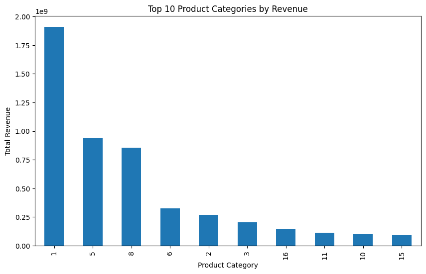

```python
plt.figure(figsize=(10,6))

top_categories.plot(kind="bar")

plt.title("Top 10 Product Categories by Revenue")
plt.xlabel("Product Category")
plt.ylabel("Total Revenue")

plt.show()
```

Category 1 is the top revenue contributor.

Categories 5 and 8 are the next strongest performers.

Revenue is concentrated in a few categories.

Lower-performing categories need further analysis to identify growth opportunities.

Recommendation: Focus on top categories while improving weaker ones.

# Product Category by Average Purchase

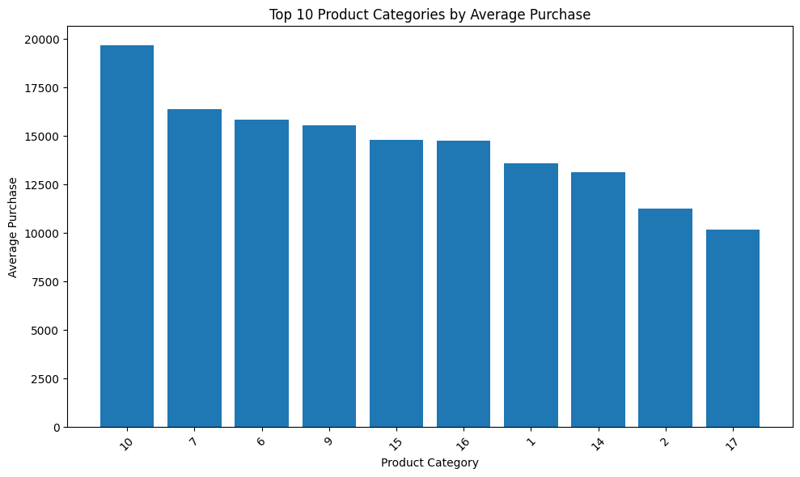

```python
# Top 10 product categories by average purchase
category_avg = (
    df.groupby("Product_Category_1")["Purchase"]
      .mean()
      .sort_values(ascending=False)
      .head(10)
)

# Bar graph
plt.figure(figsize=(10, 6))

plt.bar(category_avg.index.astype(str), category_avg.values)

plt.xlabel("Product Category")
plt.ylabel("Average Purchase")
plt.title("Top 10 Product Categories by Average Purchase")

plt.xticks(rotation=45)
plt.tight_layout()
plt.show()
```

Category 10 has the highest average purchase value.

Categories 7, 6, and 9 also show strong customer spending.

Recommendation: Focus on high-value categories and improve the average purchase value of weaker categories.

# Customer-Level Analysis

```python
customer_clv = (
    df.groupby("User_ID")
    .agg(Total_Purchase=("Purchase", "sum"), Number_of_Transactions=("Purchase", "count"))
    .reset_index()
)

# Avg order value — spend per line item, NOT lifetime value
customer_clv["Avg_Order_Value"] = customer_clv["Total_Purchase"] / customer_clv["Number_of_Transactions"]

customer_clv.head()
```

|  | User_ID | Total_Purchase | Number_of_Transactions | Avg_Order_Value |
| --- | --- | --- | --- | --- |
| 0 | 1000001 | 334093 | 35 | 9545.514286 |
| 1 | 1000002 | 810472 | 77 | 10525.610390 |
| 2 | 1000003 | 341635 | 29 | 11780.517241 |
| 3 | 1000004 | 206468 | 14 | 14747.714286 |
| 4 | 1000005 | 821001 | 106 | 7745.292453 |

This dataset has no transaction date, so a projected CLV can't be calculated.

Total_Purchase is used here as a CLV proxy (cumulative spend to date).

Avg_Order_Value is a separate metric — average spend per line item, not lifetime value.

```python
category_cols = [
    "Product_Category_1",
    "Product_Category_2",
    "Product_Category_3"
]

category_breadth = (
    df.groupby("User_ID")[category_cols]
      .apply(lambda x: x.stack().nunique())
      .reset_index(name="Category_Breadth")
)

category_breadth.head()
```

|  | User_ID | Category_Breadth |
| --- | --- | --- |
| 0 | 1000001 | 15 |
| 1 | 1000002 | 16 |
| 2 | 1000003 | 12 |
| 3 | 1000004 | 12 |
| 4 | 1000005 | 17 |

```python
df["Stay_Years"] = (
    df["Stay_In_Current_City_Years"]
    .replace("4+", 4)
    .astype(int)
)
```

```python
city_loyalty = (
    df.groupby("City_Category")
      .agg(
          Avg_Purchase=("Purchase", "mean"),
          Stay_Years=("Stay_Years", "mean")
      )
      .reset_index()
)

city_loyalty["City_Loyalty_Index"] = (
    city_loyalty["Avg_Purchase"] *
    city_loyalty["Stay_Years"]
)

city_loyalty = city_loyalty.round(2)

city_loyalty
```

|  | City_Category | Avg_Purchase | Stay_Years | City_Loyalty_Index |
| --- | --- | --- | --- | --- |
| 0 | A | 8911.94 | 1.81 | 16121.43 |
| 1 | B | 9151.30 | 1.88 | 17159.51 |
| 2 | C | 9719.92 | 1.88 | 18259.60 |

```python
customer_analysis = (
    df.groupby("User_ID")
      .agg(
          Total_Purchase=("Purchase", "sum"),
          Transactions=("Purchase", "count")
      )
      .reset_index()
)

customer_analysis.head()
```

|  | User_ID | Total_Purchase | Transactions |
| --- | --- | --- | --- |
| 0 | 1000001 | 334093 | 35 |
| 1 | 1000002 | 810472 | 77 |
| 2 | 1000003 | 341635 | 29 |
| 3 | 1000004 | 206468 | 14 |
| 4 | 1000005 | 821001 | 106 |

```python
# Top 10 Customers
top_customers = customer_analysis.sort_values(
    "Total_Purchase",
    ascending=False
).head(10)

top_customers
```

|  | User_ID | Total_Purchase | Transactions |
| --- | --- | --- | --- |
| 4166 | 1004277 | 10536909 | 979 |
| 1634 | 1001680 | 8699596 | 1026 |
| 2831 | 1002909 | 7577756 | 718 |
| 1885 | 1001941 | 6817493 | 898 |
| 416 | 1000424 | 6573609 | 694 |
| 4335 | 1004448 | 6566245 | 575 |
| 5683 | 1005831 | 6512433 | 727 |
| 981 | 1001015 | 6511314 | 740 |
| 3297 | 1003391 | 6477160 | 698 |
| 1142 | 1001181 | 6387961 | 862 |

***Top 10 Customers by Total Purchase***

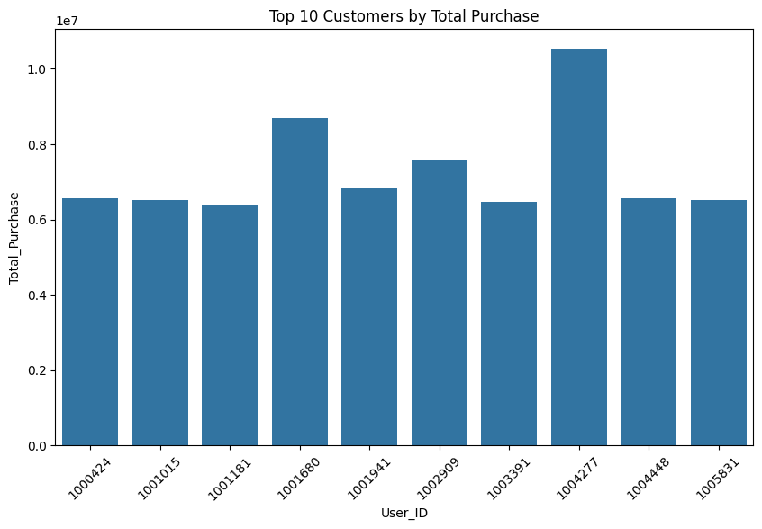

```python
plt.figure(figsize=(10,6))

sns.barplot(
    data=top_customers,
    x="User_ID",
    y="Total_Purchase"
)

plt.title("Top 10 Customers by Total Purchase")

plt.xticks(rotation=45)

plt.show()
```

```python
# Customer Segmentation
customer_analysis["Customer_Segment"] = pd.qcut(
    customer_analysis["Total_Purchase"],
    q=3,
    labels=["Low Value", "Medium Value", "High Value"]
)
```

```python
customer_analysis["Customer_Segment"].value_counts()
```

```
Low Value       1964
High Value      1964
Medium Value    1963
Name: Customer_Segment, dtype: int64
```

```python
customer_analysis.groupby(
    "Customer_Segment"
)["Total_Purchase"].agg(
    ["count", "mean", "sum"]
)
```

| Customer_Segment | count | mean | sum |
| --- | --- | --- | --- |
| Low Value | 1964 | 1.879863e+05 | 369205122 |
| Medium Value | 1963 | 5.425764e+05 | 1065077527 |
| High Value | 1964 | 1.864323e+06 | 3661530093 |

# Cross-Selling Analysis

It identifies which products are often purchased together.

This helps businesses recommend related products and increase sales.

```python
# Cross-Selling Analysis

valid_df = df[df["Product_Category_2"] != "Unknown"]

cross_sell = (
    valid_df
    .groupby(["Product_Category_1", "Product_Category_2"])
    .size()
    .reset_index(name="Number_of_Purchases")
    .sort_values("Number_of_Purchases", ascending=False)
    .reset_index(drop=True)
)

cross_sell["Purchase_Percentage"] = (
    cross_sell["Number_of_Purchases"] / len(valid_df) * 100
).round(2)

cross_sell.head(10)
```

|  | Product_Category_1 | Product_Category_2 | Number_of_Purchases | Purchase_Percentage |
| --- | --- | --- | --- | --- |
| 0 | 1 | 2 | 49217 | 13.07 |
| 1 | 5 | 8 | 31670 | 8.41 |
| 2 | 5 | 14 | 25588 | 6.80 |
| 3 | 8 | 14 | 20771 | 5.52 |
| 4 | 1 | 15 | 18544 | 4.93 |
| 5 | 3 | 4 | 16858 | 4.48 |
| 6 | 1 | 8 | 15471 | 4.11 |
| 7 | 1 | 16 | 14828 | 3.94 |
| 8 | 6 | 8 | 12071 | 3.21 |
| 9 | 1 | 5 | 11267 | 2.99 |

```python
# Build top_cross_sell: top 10 category combinations with a readable label
top_cross_sell = cross_sell.head(10).copy()
top_cross_sell["Combination"] = (
    "Cat " + top_cross_sell["Product_Category_1"] + " + Cat " + top_cross_sell["Product_Category_2"]
)
```

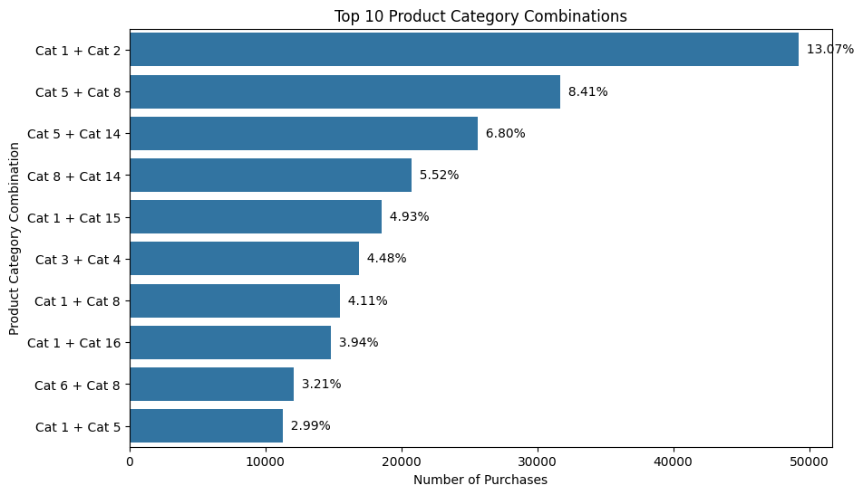

```python
plt.figure(figsize=(10, 6))

ax = sns.barplot(
    data=top_cross_sell,
    x="Number_of_Purchases",
    y="Combination",
    order=top_cross_sell["Combination"]
)
for i, row in top_cross_sell.reset_index(drop=True).iterrows():
    ax.text(
        row["Number_of_Purchases"],
        i,
        f'  {row["Purchase_Percentage"]:.2f}%',
        va="center"
    )

plt.title("Top 10 Product Category Combinations")
plt.xlabel("Number of Purchases")
plt.ylabel("Product Category Combination")

plt.show()
```

This shows customers frequently buy these two categories together, making them a good combination for cross-selling and bundle offers.”

Product Category 3 contains a high proportion of missing values (approximately 70%). Therefore, it is retained for completeness but is not prioritized in cross-selling analysis. Product Category 1 and Product Category 2 provide more reliable coverage for identifying common product combinations.

### Bivariate Analysis

“Bivariate analysis helps us understand the relationship between two variables and identify patterns or differences between them.”

Average Purchase by Gender and Marital Status

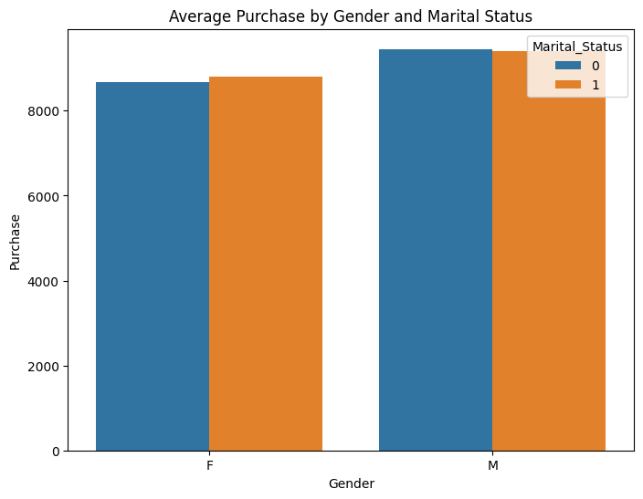

```python
plt.figure(figsize=(8,6))

sns.barplot(
    data=gender_marital,
    x="Gender",
    y="Purchase",
    hue="Marital_Status"
)

plt.title("Average Purchase by Gender and Marital Status")

plt.show()
```

“Male customers have slightly higher average purchases, while marital status shows little difference.”

```python
# Age + City Analysis
age_city = df.groupby(
    ["Age", "City_Category"]
)["Purchase"].mean().reset_index()

age_city
```

|  | Age | City_Category | Purchase |
| --- | --- | --- | --- |
| 0 | 0-17 | A | 8615.110456 |
| 1 | 0-17 | B | 8917.295308 |
| 2 | 0-17 | C | 9059.503299 |
| 3 | 18-25 | A | 8833.734084 |
| 4 | 18-25 | B | 9031.706985 |
| 5 | 18-25 | C | 9696.570919 |
| 6 | 26-35 | A | 8952.503004 |
| 7 | 26-35 | B | 9149.193178 |
| 8 | 26-35 | C | 9835.388993 |
| 9 | 36-45 | A | 8990.333997 |
| 10 | 36-45 | B | 9107.901067 |
| 11 | 36-45 | C | 9882.012654 |
| 12 | 46-50 | A | 8348.526752 |
| 13 | 46-50 | B | 9247.927129 |
| 14 | 46-50 | C | 9533.184023 |
| 15 | 51-55 | A | 9508.505001 |
| 16 | 51-55 | B | 9340.911392 |
| 17 | 51-55 | C | 9780.380806 |
| 18 | 55+ | A | 8485.945424 |
| 19 | 55+ | B | 9803.560635 |
| 20 | 55+ | C | 9385.316939 |

Average Purchase by Age and City

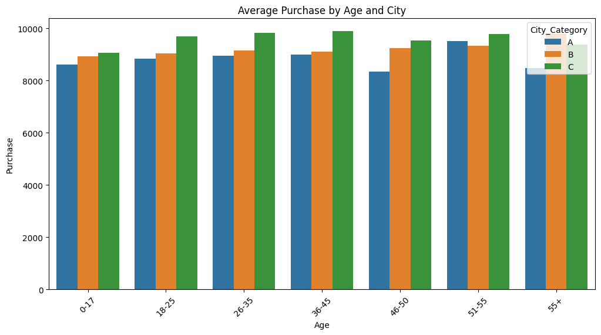

```python
plt.figure(figsize=(12,6))

sns.barplot(
    data=age_city,
    x="Age",
    y="Purchase",
    hue="City_Category"
)

plt.title("Average Purchase by Age and City")

plt.xticks(rotation=45)

plt.show()
```

“City C has the highest average purchase across most age groups, while City A is generally lower.”

**Correlation_Analysis** “Correlation analysis shows how strongly two numerical variables are related.”

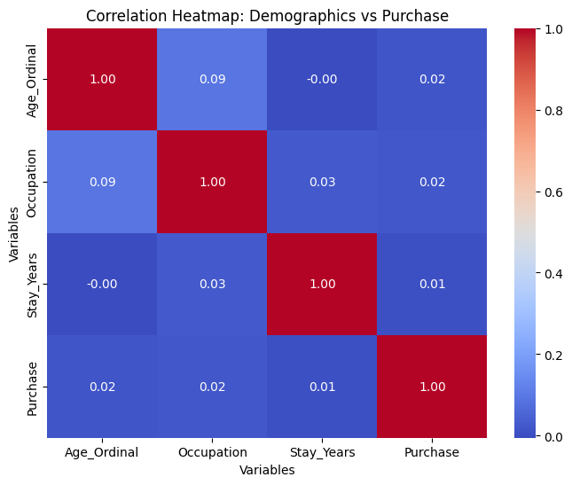

```python
# Encode Age ordinally so it can be used in correlation
age_order = {
    "0-17": 0, "18-25": 1, "26-35": 2, "36-45": 3,
    "46-50": 4, "51-55": 5, "55+": 6
}
df["Age_Ordinal"] = df["Age"].map(age_order)

# Select meaningful numerical variables
corr_data = df[["Age_Ordinal", "Occupation", "Stay_Years", "Purchase"]]

# Calculate correlation
correlation_matrix = corr_data.corr()

# Plot correlation heatmap
plt.figure(figsize=(8, 6))
sns.heatmap(correlation_matrix, annot=True, cmap="coolwarm", fmt=".2f")
plt.title("Correlation Heatmap: Demographics vs Purchase")
plt.xlabel("Variables")
plt.ylabel("Variables")
plt.show()
```

None of the demographic variables show a meaningful linear relationship with Purchase:

Age_Ordinal (0.02), Occupation (0.02), and Stay_Years (0.01) are all effectively zero.

Age and Occupation show a weak relationship with each other (0.09), but neither correlates with spend.

None of the demographic variables show a meaningful linear relationship with Purchase:

Age_Ordinal (0.02), Occupation (0.02), and Stay_Years (0.01) are all effectively zero.

Age and Occupation show a weak relationship with each other (0.09), but neither correlates with spend.

```python
age_purchase = df.groupby("Age")["Purchase"].mean().reset_index()

age_purchase
```

|  | Age | Purchase |
| --- | --- | --- |
| 0 | 0-17 | 8933.464640 |
| 1 | 18-25 | 9169.663606 |
| 2 | 26-35 | 9252.690633 |
| 3 | 36-45 | 9331.350695 |
| 4 | 46-50 | 9208.625697 |
| 5 | 51-55 | 9534.808031 |
| 6 | 55+ | 9336.280459 |

Average Purchase by Age Group

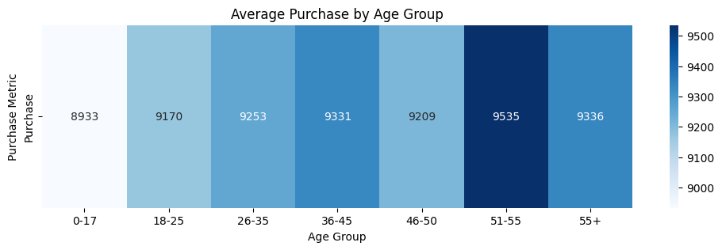

```python
age_purchase_matrix = age_purchase.set_index("Age").T

plt.figure(figsize=(12, 3))

sns.heatmap(
    age_purchase_matrix,
    annot=True,
    fmt=".0f",
    cmap="Blues"
)

plt.title("Average Purchase by Age Group")
plt.xlabel("Age Group")
plt.ylabel("Purchase Metric")

plt.show()
```

“Purchase is highest for the 51–55 age group and lowest for the 0–17 age group.”

Average Purchase by Age Group and Gender

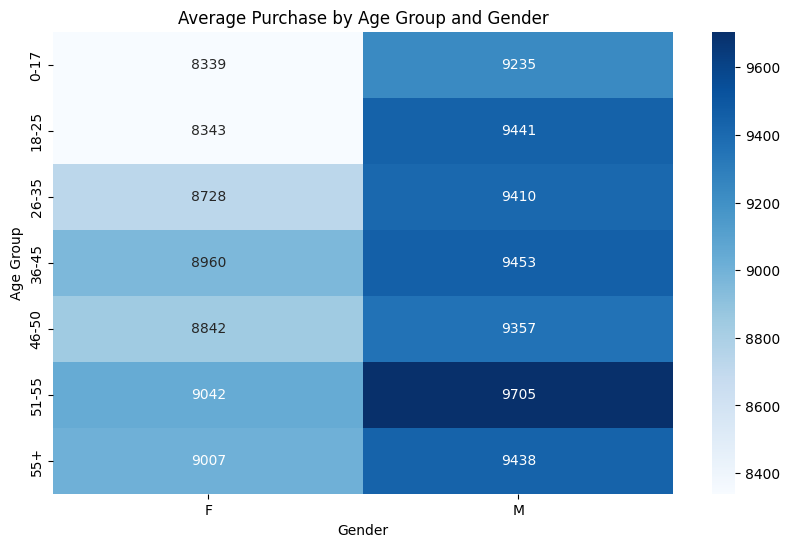

```python
demo_heatmap = pd.pivot_table(
    df,
    values="Purchase",
    index="Age",
    columns="Gender",
    aggfunc="mean"
)

plt.figure(figsize=(10, 6))

sns.heatmap(
    demo_heatmap,
    annot=True,
    fmt=".0f",
    cmap="Blues"
)

plt.title("Average Purchase by Age Group and Gender")
plt.xlabel("Gender")
plt.ylabel("Age Group")

plt.show()
```

“Male customers have higher average purchases than females in every age group.”

Average Purchase by Age Group and City

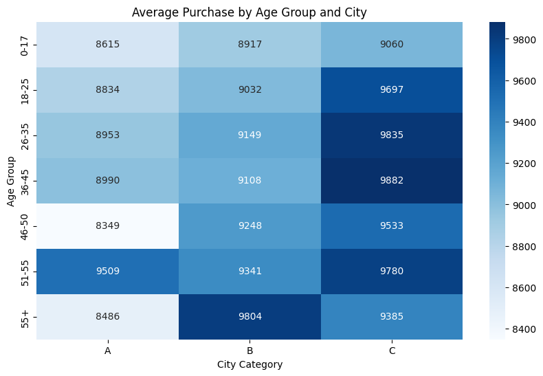

```python
city_age_heatmap = pd.pivot_table(
    df,
    values="Purchase",
    index="Age",
    columns="City_Category",
    aggfunc="mean"
)

plt.figure(figsize=(10, 6))

sns.heatmap(
    city_age_heatmap,
    annot=True,
    fmt=".0f",
    cmap="Blues"
)

plt.title("Average Purchase by Age Group and City")
plt.xlabel("City Category")
plt.ylabel("Age Group")

plt.show()
```

“City C has the highest average purchase across most age groups, while City A is generally lower.”

# Statistical Hypothesis Testing

“Statistical hypothesis testing helps us determine whether the observed differences in purchase behavior are statistically significant.”

Gender H0

There is no significant difference in purchase between males and females.

H1

There is a significant difference.

```python
from scipy.stats import ttest_ind

# Purchase values for male customers
male = df[df["Gender"] == "M"]["Purchase"]

# Purchase values for female customers
female = df[df["Gender"] == "F"]["Purchase"]

# Independent t-test
t_stat, p_value = ttest_ind(male, female)

print("t_stat:", round(t_stat, 2))
print("p_value:", p_value)

# Decision
if p_value < 0.05:
    print("Reject H0: There is a significant difference in average purchase between male and female customers.")
else:
    print("Fail to reject H0: There is no significant difference in average purchase between male and female customers.")
```

```
t_stat: 44.84
p_value: 0.0
Reject H0: There is a significant difference in average purchase between male and female customers.
```

“Since the p-value is 0.0 (< 0.05), we reject H₀. There is a significant difference in average purchase between male and female customers.”

# Marital Status Hypothesis Test

```python
single=df[df["Marital_Status"]==0]["Purchase"]
married=df[df["Marital_Status"]==1]["Purchase"]

t_stat,p_value=ttest_ind(single,married)

print("t_stat:",round((t_stat),2))
print("p_value:",round((p_value),2))

if p_value < 0.05:
    print("Reject H0")
    print("There is a significant difference in average purchase between single and married customers")
else:
    print("Fail to Reject H0")
    print("There is no significant difference in average purchase between single and married customers")
```

```
t_stat: 0.34
p_value: 0.73
Fail to Reject H0
There is no significant difference in average purchase between single and married customers
```

“Since the p-value is 0.73 (> 0.05), we fail to reject H₀. There is no significant difference in average purchase between single and married customers.”

ANOVA — City

```python
city_A=  df[df["City_Category"]=="A"]["Purchase"]
city_B=  df[df["City_Category"]=="B"]["Purchase"]
city_c=  df[df["City_Category"]=="C"]["Purchase"]

f_stat,p_value=stats.f_oneway(city_A,city_B,city_c)

print("f_stat:",f_stat)
print("p_value:",p_value)


if p_value < 0.05:
    print("Reject H0")
    print("There is a significant difference in average purchase among the city categories.")
else:
    print("Fail to Reject H0")
    print("There is no significant difference in average purchase among the city categories.")
```

```
f_stat: 1130.7459610102974
p_value: 0.0
Reject H0
There is a significant difference in average purchase among the city categories.
```

“Since the p-value is 0.0 (< 0.05), we reject H₀. There is a significant difference in average purchase among the three city categories.”

# ANOVA — Age Groups

```python
age_groups = [
    df[df["Age"] == age]["Purchase"]
    for age in df["Age"].unique()
]

f_stat, p_value = stats.f_oneway(*age_groups)

print("F-statistic:", f_stat)
print("P-value:", p_value)
```

```
F-statistic: 40.57579909450408
P-value: 1.0535639392516708e-49
```

“Since the p-value is very small (< 0.05), we reject H₀. Average purchase differs significantly across age groups.”

**Final Business Insights**

26–35 age group is the largest customer segment.

City B has the highest number of transactions.

Male customers dominate transactions and purchase value.

Some product categories generate higher revenue than others.

High-value customers contribute significantly to total revenue.

Gender has a significant impact on purchase behavior.

Marital status has no significant impact on average purchase.

Some product categories are frequently purchased together, creating cross-selling opportunities.

**Business Recommendations**

- Target the 26–35 age group with personalized offers and campaigns, as they form the largest customer segment.
- Focus marketing efforts on City B to strengthen sales in the highest-transaction market.
- Target male customers with relevant promotions, while also creating campaigns to increase female customer participation.
- Promote high-revenue product categories through discounts, featured placements, and targeted campaigns.
- Retain high-value customers using loyalty programs, exclusive offers, and personalized recommendations.
- Use gender-based purchase insights to create more targeted marketing strategies, as purchase behavior differs significantly by gender.
- Avoid heavily segmenting offers by marital status, since it does not significantly affect average purchase value.
- Create bundle offers for frequently purchased product combinations to increase cross-selling and average order value.

**Overall Recommendation**

“Focus on high-performing customer segments, cities, and products while using personalized promotions and cross-selling strategies to increase sales and customer value.”

Recommendation 1 — Target high-value customers

Create loyalty offers for customers in the High Value segment.

Recommendation 2 — Gender-based campaigns

Since your hypothesis test shows a significant gender difference, consider differentiated campaigns.

Recommendation 3 — Focus on high-performing products

Promote products/categories generating the highest revenue.

Recommendation 4 — Cross-selling

Bundle frequently purchased product categories.

Recommendation 5 — City-specific marketing

Use city-level purchase behavior to create targeted campaigns.

```python
df.to_csv("cleaned__black.csv", index=False)
```

```python
import pandas as pd
from sqlalchemy import create_engine
```

```python
df = pd.read_csv("cleaned__black.csv")
```

```python
df
```

|  | User_ID | Product_ID | Gender | Age | Occupation | City_Category | Stay_In_Current_City_Years | Marital_Status | Product_Category_1 | Product_Category_2 | Product_Category_3 | Purchase | Stay_Years | Age_Ordinal |
| --- | --- | --- | --- | --- | --- | --- | --- | --- | --- | --- | --- | --- | --- | --- |
| 0 | 1000001 | P00069042 | F | 0-17 | 10 | A | 2 | 0 | 3 | Unknown | Unknown | 8370 | 2 | 0 |
| 1 | 1000001 | P00248942 | F | 0-17 | 10 | A | 2 | 0 | 1 | 6 | 14 | 15200 | 2 | 0 |
| 2 | 1000001 | P00087842 | F | 0-17 | 10 | A | 2 | 0 | 12 | Unknown | Unknown | 1422 | 2 | 0 |
| 3 | 1000001 | P00085442 | F | 0-17 | 10 | A | 2 | 0 | 12 | 14 | Unknown | 1057 | 2 | 0 |
| 4 | 1000002 | P00285442 | M | 55+ | 16 | C | 4+ | 0 | 8 | Unknown | Unknown | 7969 | 4 | 6 |
| ... | ... | ... | ... | ... | ... | ... | ... | ... | ... | ... | ... | ... | ... | ... |
| 550063 | 1006033 | P00372445 | M | 51-55 | 13 | B | 1 | 1 | 20 | Unknown | Unknown | 368 | 1 | 5 |
| 550064 | 1006035 | P00375436 | F | 26-35 | 1 | C | 3 | 0 | 20 | Unknown | Unknown | 371 | 3 | 2 |
| 550065 | 1006036 | P00375436 | F | 26-35 | 15 | B | 4+ | 1 | 20 | Unknown | Unknown | 137 | 4 | 2 |
| 550066 | 1006038 | P00375436 | F | 55+ | 1 | C | 2 | 0 | 20 | Unknown | Unknown | 365 | 2 | 6 |
| 550067 | 1006039 | P00371644 | F | 46-50 | 0 | B | 4+ | 1 | 20 | Unknown | Unknown | 490 | 4 | 4 |

550068 rows × 14 columns

```python
engine = create_engine("mysql+pymysql://root:1234@localhost:3306/blackfriday")
```

```python
df.to_sql(
    name="sales",
    con=engine,
    if_exists="replace",
    index=False
)
```

```
550068
```

```python
print(df.shape)
df.head()
```

```
(550068, 14)
```

|  | User_ID | Product_ID | Gender | Age | Occupation | City_Category | Stay_In_Current_City_Years | Marital_Status | Product_Category_1 | Product_Category_2 | Product_Category_3 | Purchase | Stay_Years | Age_Ordinal |
| --- | --- | --- | --- | --- | --- | --- | --- | --- | --- | --- | --- | --- | --- | --- |
| 0 | 1000001 | P00069042 | F | 0-17 | 10 | A | 2 | 0 | 3 | Unknown | Unknown | 8370 | 2 | 0 |
| 1 | 1000001 | P00248942 | F | 0-17 | 10 | A | 2 | 0 | 1 | 6 | 14 | 15200 | 2 | 0 |
| 2 | 1000001 | P00087842 | F | 0-17 | 10 | A | 2 | 0 | 12 | Unknown | Unknown | 1422 | 2 | 0 |
| 3 | 1000001 | P00085442 | F | 0-17 | 10 | A | 2 | 0 | 12 | 14 | Unknown | 1057 | 2 | 0 |
| 4 | 1000002 | P00285442 | M | 55+ | 16 | C | 4+ | 0 | 8 | Unknown | Unknown | 7969 | 4 | 6 |